# Application of Bispectrum and Convolutional Neural Network on Time Series Data (Part II)

# Convolutional Neural Network

- Convolutional neural networks(CNN) are deep artificial neural networks that are used primarily to classify images, cluster them by similarity and perform object recognition within scenes.
- Because bi-spectrum form of the time series data is essentially a 2-D image, then the time series classification problem could converte to the image classification problem.
- In an intuitive way, the algorithm works by analysing and comparing several previously classified images (training process), testing and fine tuning the model (updating the weights), until converging into an accurate classification.

## Components

[figure not shown]

### Convolution layer

- To extract features from the input image.

Convolution preserves the spatial relationship between pixels by learning image features using small squares of input data. A filter slides over the input image to produce a feature map. The convolution of another filter over the same image gives a different feature map as shown.

[figure not shown]

### Activation layer

- Introducing Non-linearity.

Non-linear means that the output cannot be reproduced from a linear combination of the inputs. Without a non-linear activation function in the network, a CNN, no matter how many layers it had, would behave just like a single-layer perceptron, because summing these layers would give us just another linear function.

- ReLU(Rectified Linear Units): $f(x)=\max(0,x)$. It increases the nonlinear properties of the decision function and of the overall network without affecting the receptive fields of the convolution layer.

### Pooling layer

- Reduces the dimensionality of each feature map but retains the most important information.
- Controls Overfit
- Introduces non-linearity (only Max pooling).

Spatial Pooling can be of different types: Max, Average, Sum etc.

[figure not shown]

We slide our 2 x 2 window by 2 cells (also called ‘stride’) and take the maximum value in each region. As shown in Figure 10, this reduces the dimensionality of our feature map. Pooling operation is applied separately to each feature map.

### Fully Connected layer

- Use features captured before classifying the input image into various classes.

"Fully Connected” implies every neuron in the previous layer is connected to every neuron on the next layer.

The sum of output probabilities from the Fully Connected Layer is 1. This is ensured by using the Softmax as the activation function in the output layer of the Fully Connected Layer. The Softmax function takes a vector of arbitrary real-valued scores and squashes it to a vector of values between zero and one that sum to one.

## Model

```python
########################## Build Model ########################

keras.backend.set_image_data_format('channels_last')  # TF dimension ordering in this code

nb_classes = len(np.unique(np.concatenate([train_label,test_label])))
batch_size = 30
nb_epochs = 1000

#### Reshape datasets ####

train_set = train_set[..., np.newaxis]
test_set = test_set[..., np.newaxis]

#### Add Dummy to label (Scale) ####

train_label = train_label[..., np.newaxis]   # reshape
test_label = test_label[..., np.newaxis]     # reshape

train_label = (train_label - train_label.min())/(train_label.max() - train_label.min())*(nb_classes - 1)
y_train = keras.utils.to_categorical(train_label, nb_classes)

test_label = (test_label - test_label.min())/(test_label.max() - test_label.min())*(nb_classes - 1)
y_test = keras.utils.to_categorical(test_label, nb_classes)


#### Start Model ####

x_train = train_set
x_test = test_set

model = Sequential()
model.add(Conv2D(filters = 32, kernel_size = (3, 3), padding='same', input_shape=x_train.shape[1:]))
# model.add(Activation('relu'))
# model.add(BatchNormalization())
# model.add(Conv2D(32, (3, 3)))
model.add(Activation('relu'))
model.add(MaxPooling2D(pool_size=(2, 2)))
model.add(Dropout(0.25))

model.add(Conv2D(64, (3, 3), padding='same'))
# model.add(Activation('relu'))
# model.add(BatchNormalization())
# model.add(Conv2D(64, (3, 3)))
model.add(Activation('relu'))
model.add(MaxPooling2D(pool_size=(2, 2)))
model.add(Dropout(0.25))

model.add(Conv2D(32, (3, 3), padding='same'))
model.add(Activation('relu'))
model.add(MaxPooling2D(pool_size=(2, 2)))
model.add(Dropout(0.25))

model.add(Flatten())
model.add(Dense(512))
model.add(Activation('relu'))
model.add(Dropout(0.5))
model.add(Dense(nb_classes))
model.add(Activation('softmax'))

#######################################################################

opt = keras.optimizers.Adam()

model.compile(loss='categorical_crossentropy', optimizer=opt, metrics=['accuracy'])

model.fit(x_train, y_train, batch_size=batch_size, epochs=nb_epochs, validation_data=(x_test, y_test), shuffle=True)
```

## Result

[output not shown]

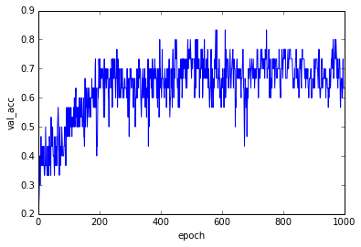

```python
import matplotlib.pyplot as plt
%pylab inline
with open("result", "r") as f:
	result = f.read().splitlines()
f.close()

result = filter(lambda e: "val_acc" in e, result)
result = map(lambda e: e.split("val_acc: ")[1], result)
result = map(float, result)
print result[900:1000]
print '-------------------------------'
print "Average:", mean(result[900:])
print '-------------------------------'
print "Max:", max(result)

plt.plot(result)
plt.ylabel('val_acc')
plt.xlabel('epoch')
# plt.show()
```